# Quantitative Text Analysis

Lab Session: Week 11

Author

Instructor: Yen-Chieh Liao and Stefan Müller

Published

April 15, 2024

## Installation

Practice installing this R wrapper by following the instructions provided, or by consulting the flaiR documentation at `https://davidycliao.github.io/flaiR/`.

### Environment Setup: Python, R, and RStudio

**Following Instructions Below:**

Step 1: The installation consists of two parts:

- First, install Python 3.8 or higher (avoid developmental versions and the very latest release for compatibility reasons).
- Secondly, install R 4.2.0 or higher. For official python reference: https://flairnlp.github.io/flair/v0.13.1/. In R, our research group has a R wrapper — [flaiR](https://davidycliao.github.io/flaiR/).

**System Requirement:**

- Python (>= 3.10.x)
- R (>= 4.2.0)
- RStudio *(The GUI interface allows users to adjust and manage the Python environment in R)*
- Anaconda or miniconda *(Highly recommended for managing the Python environment, the Conda environment in RStudio can be easily changed by `Tools ➟ Global Options ➟ Python`..)*

Step 2: Now, install **flaiR** in Rstudio:

```
install.packages("remotes")
remotes::install_github("davidycliao/flaiR", force = TRUE)

library(flaiR)
#> flaiR: An R Wrapper for Accessing Flair NLP 0.13.0
```

**Notice:**

- When first installed, **flaiR** automatically detects whether you have Python 3.8 or higher. If not, **flaiR** will skip the automatic installation of Python and flair NLP. In this case, you will need to manually install it yourself and reload {`flaiR`} again. If you have correct Python installed, the {`flaiR`} will automatically install flair Python NLP in your global environment. If you are using {reticulate}, **flaiR** will typically assume the **r-reticulate** environment by default. At the same time, you can use `py_config()` to check the location of your environment. Please note that flaiR will directly install flair NLP in the Python environment that your R is using. This environment can be adjusted through *RStudio* by navigating to **`Tools -> Global Options -> Python`**. If there are any issues with the installation, feel free to ask question in the Slack .
- *I suggest not directly installing Python and RStudio, along with R, from the University’s AnyApp platform.*

## Word Embeddings

`Sentence:` a class is used to tokenize the input text.

`WordEmbeddings:` a class is used to embed tokenized text.

```r
library(flaiR)
Sentence <- flair_data()$Sentence
WordEmbeddings <- flair_embeddings()$WordEmbeddings
```

### Classic Word Embeddings

- GloVe embeddings are Pytorch vectors of dimensionality 100.
- For English, Flair provides a few more options. Here, you can use ‘en-glove’ and ‘en-extvec’ with the WordEmbeddings class.

| ID | Language | Embedding |
| --- | --- | --- |
| ‘en-glove’ (or ‘glove’) | English | GloVe embeddings |
| ‘en-extvec’ (or ‘extvec’) | English | Komninos embeddings |
| ‘en-crawl’ (or ‘crawl’) | English | FastText embeddings over Web crawls |
| ‘en-twitter’ (or ‘twitter’) | English | Twitter embeddings |
| ‘en-turian’ (or ‘turian’) | English | Turian embeddings (small) |
| ‘en’ (or ‘en-news’ or ‘news’) | English | FastText embeddings over wikipedia data |

- Flair NLP supports a variety of embeddings. For detailed information, please see: [Classic Word Embeddings in Flair](https://github.com/flairNLP/flair/blob/master/resources/docs/embeddings/CLASSIC_WORD_EMBEDDINGS.md).

```r
embedding <- WordEmbeddings("glove")
```

- Print the class

```r
print(embedding)
```

```
WordEmbeddings(
  'glove'
  (embedding): Embedding(400001, 100)
)
```

### Tokenize & Embed

```r
# Tokenize the text
sentence = Sentence("King Queen man woman Paris London apple orange Taiwan Dublin Bamberg")

# Embed the sentence text using the loaded model.
embedding$embed(sentence)
```

```
[[1]]
Sentence[11]: "King Queen man woman Paris London apple orange Taiwan Dublin Bamberg"
```

- The `sentence` is being embedded with the corresponding vector from the model, store to the list.

```r
sen_list <- list()
for (i in seq_along(sentence$tokens)) {
  # store the tensor vectors to numeric vectors
  sen_list[[i]] <- as.vector(sentence$tokens[[i]]$embedding$numpy())
}
```

- Extract the name list to R vector

```r
token_texts <- sapply(sentence$tokens, function(token) token$text)
```

- form the dataframe.

```r
sen_df <- do.call(rbind, lapply(sen_list, function(x) t(data.frame(x))))
sen_df <- as.data.frame(sen_df)
rownames(sen_df) <- token_texts
print(sen_df[,1:20])
```

```
                V1        V2        V3        V4         V5       V6       V7
King    -0.3230700 -0.876160  0.219770  0.252680  0.2297600  0.73880 -0.37954
Queen   -0.5004500 -0.708260  0.553880  0.673000  0.2248600  0.60281 -0.26194
man      0.3729300  0.385030  0.710860 -0.659110 -0.0010128  0.92715  0.27615
woman    0.5936800  0.448250  0.593200  0.074134  0.1114100  1.27930  0.16656
Paris    0.9260500 -0.228180 -0.255240  0.739970  0.5007200  0.26424  0.40056
London   0.6055300 -0.050886 -0.154610 -0.123270  0.6627000 -0.28506 -0.68844
apple   -0.5985000 -0.463210  0.130010 -0.019576  0.4603000 -0.30180  0.89770
orange  -0.1496900  0.164770 -0.355320 -0.719150  0.6213000  0.74140  0.68959
Taiwan   0.0061832  0.117350  0.535380  0.787290  0.6427700 -0.56057 -0.35941
Dublin  -0.4281400 -0.168970  0.035079  0.133170  0.4115600  1.03810 -0.32697
Bamberg  0.4854000 -0.296800  0.103520 -0.250310  0.4100900  0.45147 -0.08002
               V8       V9        V10       V11       V12      V13      V14
King    -0.353070 -0.84369 -1.1113000 -0.302660  0.331780 -0.25113  0.30448
Queen    0.738720 -0.65383 -0.2160600 -0.338060  0.244980 -0.51497  0.85680
man     -0.056203 -0.24294  0.2463200 -0.184490  0.313980  0.48983  0.09256
woman    0.240700  0.39045  0.3276600 -0.750340  0.350070  0.76057  0.38067
Paris    0.561450  0.17908  0.0504640  0.024095 -0.064805 -0.25491  0.29661
London   0.491350 -0.68924  0.3892600  0.143590 -0.488020  0.15746  0.83178
apple   -0.656340  0.66858 -0.4916400  0.037557 -0.050889  0.64510 -0.53882
orange   0.403710 -0.24239  0.1774000 -0.950790 -0.188870 -0.02344  0.49681
Taiwan  -0.157720  0.97407 -0.1026900 -0.852620 -0.058598  1.19080  0.19279
Dublin   0.333970 -0.16726 -0.0034566 -0.361420 -0.067648 -0.45075  1.43470
Bamberg -0.264430 -0.47231  0.0170920  0.036594 -0.483970 -0.18393  0.68727
              V15        V16       V17       V18       V19      V20
King    -0.077491 -0.8981500  0.092496 -1.140700 -0.583240  0.66869
Queen   -0.371990 -0.5882400  0.306370 -0.306680 -0.218700  0.78369
man      0.329580  0.1505600  0.573170 -0.185290 -0.522770  0.46191
woman    0.175170  0.0317910  0.468490 -0.216530 -0.462820  0.39967
Paris   -0.476020  0.2424400 -0.067045 -0.460290 -0.384060 -0.36540
London  -0.279230  0.0094755 -0.112070 -0.520990 -0.371590 -0.37951
apple   -0.376500 -0.0431200  0.513840  0.177830  0.285960  0.92063
orange   0.081903 -0.3694400  1.225700 -0.119000  0.955710 -0.19501
Taiwan  -0.266930 -0.7671900  0.681310 -0.240430 -0.086499 -0.18486
Dublin  -0.591370 -0.3136400  0.602490  0.145310 -0.351880  0.18191
Bamberg  0.249500  0.2045100  0.517300  0.084214 -0.115300 -0.53820
```

## Dimension Reduction (PCA)

```r
# Set the seed for reproducibility
set.seed(123)

# Execute PCA
pca_result <- prcomp(sen_df, center = TRUE, scale. = TRUE)
word_embeddings_matrix <- as.data.frame(pca_result$x[,1:3] )
rownames(word_embeddings_matrix) <- token_texts
word_embeddings_matrix
```

```
               PC1       PC2         PC3
King    -2.9120910  1.285200 -1.95053854
Queen   -2.2413804  2.266714 -1.09020972
man     -5.6381902  2.984461  3.55462010
woman   -6.4891003  2.458607  3.56693660
Paris    3.0702212  5.039061 -2.65962020
London   5.3196216  4.368433 -2.60726627
apple    0.3362535 -8.679358 -0.44752722
orange  -0.0485467 -4.404101  0.77151480
Taiwan  -2.7993829 -4.149287 -6.33296039
Dublin   5.8994096  1.063291 -0.09271925
Bamberg  5.5031854 -2.233020  7.28777009
```

### 2D Plot

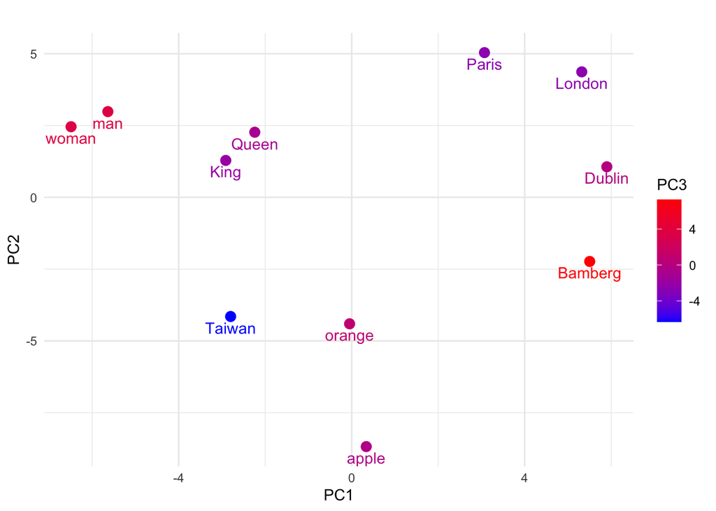

```r
library(ggplot2)
plot2D <- ggplot(word_embeddings_matrix, aes(x = PC1, y = PC2, color = PC3,
                                             label = rownames(word_embeddings_matrix))) +
  geom_point(size = 3) +
  geom_text(vjust = 1.5, hjust = 0.5) +
  scale_color_gradient(low = "blue", high = "red") +
  theme_minimal() +
  labs(title = "", x = "PC1", y = "PC2", color = "PC3")
  # guides(color = "none")
plot2D
```

### Bonus: 3D Plot

[plotly](https://plotly.com/r/) in R API: https://plotly.com/r/

```r
library(plotly)
plot3D <- plot_ly(data = word_embeddings_matrix,
                  x = ~PC1, y = ~PC2, z = ~PC3,
                  type = "scatter3d", mode = "markers",
                  marker = list(size = 5),
                  text = rownames(word_embeddings_matrix), hoverinfo = 'text')

plot3D
```

[interactive chart not shown]

## Tasks

- Use the script provided above with a different word embedding model and perform the PCA again to observe any differences that emerge?
- Create a sentence object, extract the vectors, and perform PCA again. Then, compare the results from different models.